# 모델링2(R)

서울대학교 과학데이터혁신연구소

2025년 8월

# 실습

## 1. 분석을 위해 필요한 라이브러리 및 데이터 불러오기

- `rm(list = ls())`를 이용해 R의 environment를 초기화 할 수 있습니다.

```r
rm(list = ls())
```

- 분석에 필요한 패키지들을 불러옵니다.

```r
library(dplyr)        # 데이터 처리
```

```r
library(ggcorrplot)   # 상관관계 시각화
library(ggplot2)      # 시각화
library(rpart)        # 결정나무
library(rpart.plot)   # 결정나무 시각화
library(randomForest) # 배깅 및 랜덤포레스트
library(neuralnet)    # 인공신경망
library(caret)        # 데이터 분리 및 모형 평가
library(tidyr)        # 데이터 전처리
library(pROC)         # ROC 계산
```

- KNHANES(국민건강영양조사) 2019년도 데이터를 R로 불러옵니다.
- 실습 편의상 미리 준비된 HN19_lec3.csv 파일을 불러 옵니다.
- `head()`함수를 통해 불러온 데이터의 앞부분을 확인 가능하며, `n = 5`와 같이 표시할 행의 수를 명시할 수 있습니다.

```r
hn19 <- read.csv("HN19_lec3.csv")
head(hn19, n = 5) # 데이터의 첫 5개 행 확인
```

```
##   age   HE_BMI HE_HP HE_DM_HbA1c
## 1  61 25.98739     3           3
## 2  28 16.90094     1           1
## 3  53 19.78183     2           1
## 4  50 26.63165     1           2
## 5  16       NA    NA          NA
```

## 2. 변수 생성 및 결측 처리

- 주어진 데이터로부터 BMI(체질량지수), 고혈압 여부, 당뇨 여부를 나타내는 범주형 변수를 생성합니다.
- 본래 고혈압 여부는 HE_HP에 1 = 정상, 2 = 고혈압 전단계, 3 = 고혈압으로 코딩돼 있는데 이를 hp에 0 = 정상, 1 = 고혈압 전단계 또는 고혈압으로 변환하고, 당뇨 여부는 HE_DM_HbA1c에 1 = 정상, 2 = 당뇨병 전단계, 3 = 당뇨병으로 코딩돼 있는데 이를 diabetes에 0 = 정상, 1 = 당뇨병 전단계 또는 고혈압으로 코딩합니다.
- 결측치(NA)가 포함된 행을 제거합니다.
- 분석에 필요한 변수만 선택합니다.
- `head()`와 동일한 방법으로, `tail()`을 이용해 데이터의 뒷부분을 확인할 수 있으며, `n = 3`과 같이 표시할 행의 수를 명시할 수 있습니다.

```r
hn19 <- hn19 %>%
  mutate(
    bmi = HE_BMI,
    hp = as.numeric(HE_HP %in% c(2, 3)),
    diabetes = as.numeric(HE_DM_HbA1c %in% c(2, 3))
  ) %>%
  filter(!is.na(hp), !is.na(bmi), !is.na(diabetes)) %>%
  select(age, bmi, hp, diabetes)
tail(hn19, n = 3) # 데이터의 마지막 5개 행 확인
```

```
##      age      bmi hp diabetes
## 7668  43 15.37515  0        0
## 7669  16 14.84497  0        0
## 7670   8 14.52800  0        0
```

## 3. 상관관계 분석 및 시각화

```r
cor_mat <- hn19 %>%
  select(age, bmi, hp, diabetes) %>%
  cor()
```

- 상관계수 행렬을 시각화하기 위해 `ggcorrplot`패키지의 `ggcorrplot()` 함수를 이용합니다.
- lab = TRUE: 각 셀에 상관계수 숫자를 표시
- lab_size = 5: 상관계수 숫자의 크기 지정
- tl.cex = 10: 변수명 글자 크기 지정
- colors: 상관계수 크기에 따른 색상 팔레트 설정

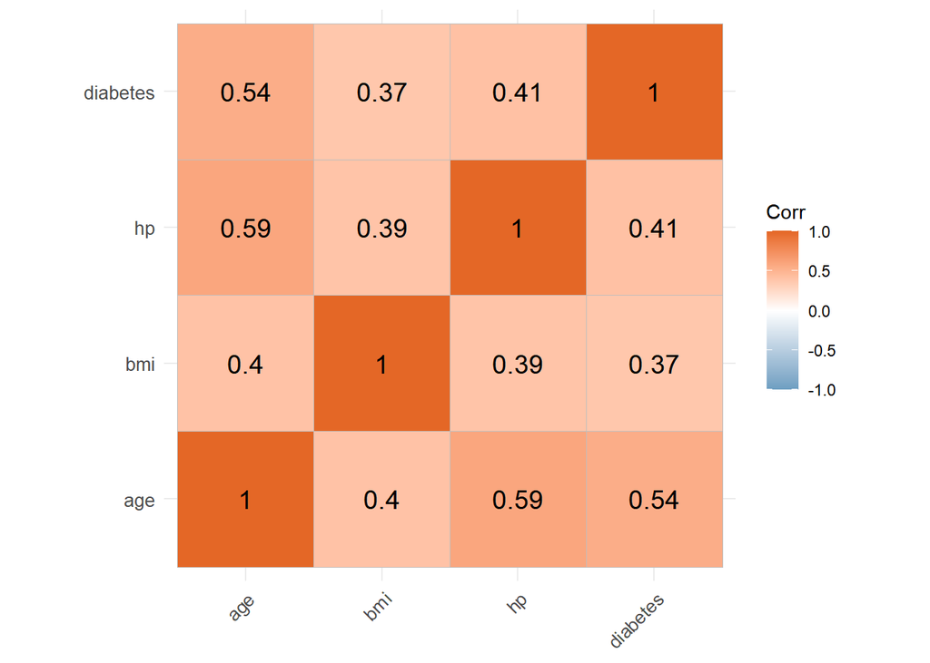

```r
ggcorrplot(
  cor_mat,
  lab = TRUE,
  lab_size = 5,
  tl.cex = 10,
  colors = c("#6D9EC1", "white", "#E46726")
)
```

## 4. BMI와 당뇨병 관계 시각화

- 변수 간 관계를 시각화하면 데이터의 패턴을 쉽게 확인할 수 있습니다.
- `ggplot2`를 이용해 반응변수와 설명변수에 대한 산점도를 그립니다.
- 설명변수 중 `BMI`를 선택해 x축으로 하고, 반응변수인 `diabetes`를 y축으로 하는 산점도를 그립니다.
- 반응변수인 `diabetes`가 0 또는 1이므로 그냥 `geom_point`를 사용하면 `y=0` 또는 `y=1`에 겹쳐지게 됩니다. 따라서 `geom_jitter`를 사용해 점들이 `y=0` 또는 `y=1` 주변으로 흩뿌려지게 합니다.

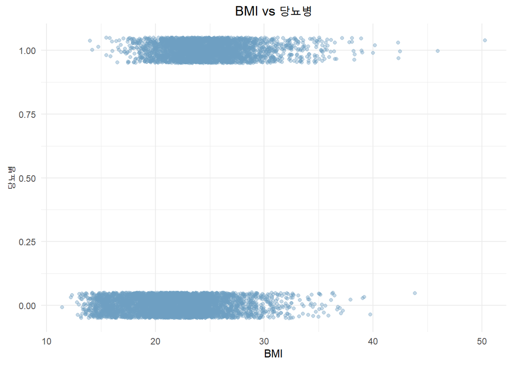

```r
ggplot(hn19, aes(x = bmi, y = diabetes)) +
  geom_jitter(
    color = "#6D9EC1",
    height = 0.05,
    width = 0,
    alpha = 0.4
  ) +
  labs(
    title = "BMI vs 당뇨병",
    x = "BMI",
    y = "당뇨병"
  ) +
  theme_minimal() +
  theme(plot.title = element_text(hjust = 0.5))
```

## 5. 로지스틱 회귀 (2변수 모형) 및 예측 확률 시각화

```r
model_logistic_2d <- glm(
  formula = diabetes ~ age + bmi,
  data = hn19,
  family = "binomial"
)
summary(model_logistic_2d)
```

```
##
## Call:
## glm(formula = diabetes ~ age + bmi, family = "binomial", data = hn19)
##
## Coefficients:
##              Estimate Std. Error z value Pr(>|z|)
## (Intercept) -6.994652   0.217239  -32.20   <2e-16 ***
## age          0.062048   0.001672   37.11   <2e-16 ***
## bmi          0.160854   0.008059   19.96   <2e-16 ***
## ---
## Signif. codes:  0 '***' 0.001 '**' 0.01 '*' 0.05 '.' 0.1 ' ' 1
##
## (Dispersion parameter for binomial family taken to be 1)
##
##     Null deviance: 10488.7  on 7669  degrees of freedom
## Residual deviance:  7472.3  on 7667  degrees of freedom
## AIC: 7478.3
##
## Number of Fisher Scoring iterations: 5
```

- 시각화를 위해, 격자 데이터를 `grid`에 생성합니다.
- 격자의 각 지점별 당뇨 확률을 계산해 `pred_logistic_2d`에 저장합니다.
- `ggplot()`을 이용해 색상으로 시각화합니다.

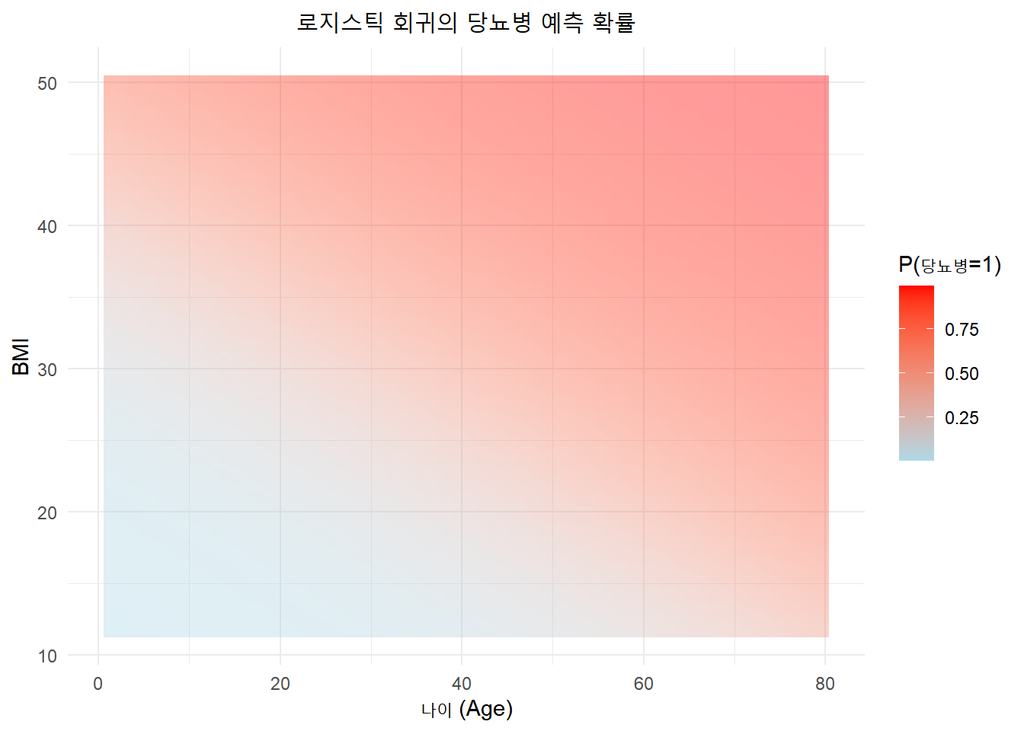

```r
age_seq <- seq(min(hn19$age), max(hn19$age), length.out = 100)
bmi_seq <- seq(min(hn19$bmi), max(hn19$bmi), length.out = 100)
grid <- expand.grid(age = age_seq, bmi = bmi_seq)

pred_logistic_2d <- predict(
  model_logistic_2d,
  newdata = grid,
  type = "response"
)

ggplot() +
  geom_tile(
    aes(
      x = grid[["age"]],
      y = grid[["bmi"]],
      fill = pred_logistic_2d
    ),
    alpha = 0.4
  ) +
  scale_fill_gradient(low = "lightblue", high = "red") +
  labs(
    title = "로지스틱 회귀의 당뇨병 예측 확률",
    x = "나이 (Age)",
    y = "BMI",
    fill = "P(당뇨병=1)"
  ) +
  theme_minimal() +
  theme(plot.title = element_text(hjust = 0.5))
```

## 6. 로지스틱 회귀 (다변량 모형) 및 잔차 진단

- 이번에는 설명변수를 3개 사용하여 `age`, `bmi`, `hp`를 설명변수로, `diabetes`를 반응변수로 하는 로지스틱 회귀모형을 적합합니다.
- summary() 함수를 통해 계수 및 유의성, 모델 적합도를 확인합니다.

```r
model_logistic <- glm(
  formula = diabetes ~ age + bmi + hp,
  data = hn19,
  family = "binomial"
)
summary(model_logistic)
```

```
##
## Call:
## glm(formula = diabetes ~ age + bmi + hp, family = "binomial",
##     data = hn19)
##
## Coefficients:
##              Estimate Std. Error z value Pr(>|z|)
## (Intercept) -6.741318   0.220841 -30.526  < 2e-16 ***
## age          0.057853   0.001831  31.589  < 2e-16 ***
## bmi          0.150998   0.008249  18.304  < 2e-16 ***
## hp           0.341577   0.063894   5.346 8.99e-08 ***
## ---
## Signif. codes:  0 '***' 0.001 '**' 0.01 '*' 0.05 '.' 0.1 ' ' 1
##
## (Dispersion parameter for binomial family taken to be 1)
##
##     Null deviance: 10489  on 7669  degrees of freedom
## Residual deviance:  7444  on 7666  degrees of freedom
## AIC: 7452
##
## Number of Fisher Scoring iterations: 5
```

- 적합한 회귀모형 `model_logistic`에 함수 `plot()`을 적용함으로써 잔차 및 진단 그래프를 확인할 수 있습니다.

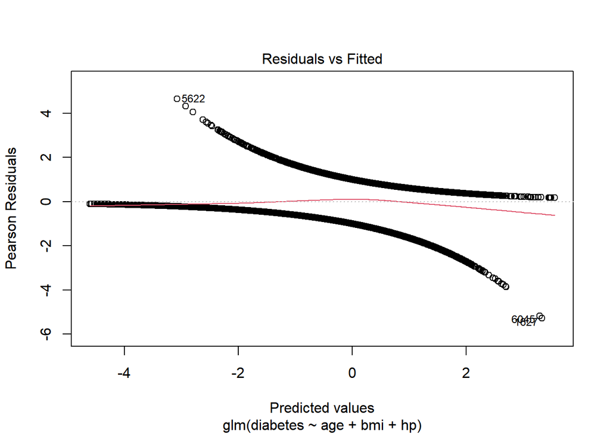

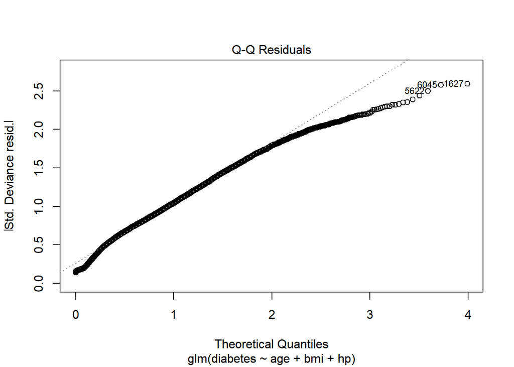

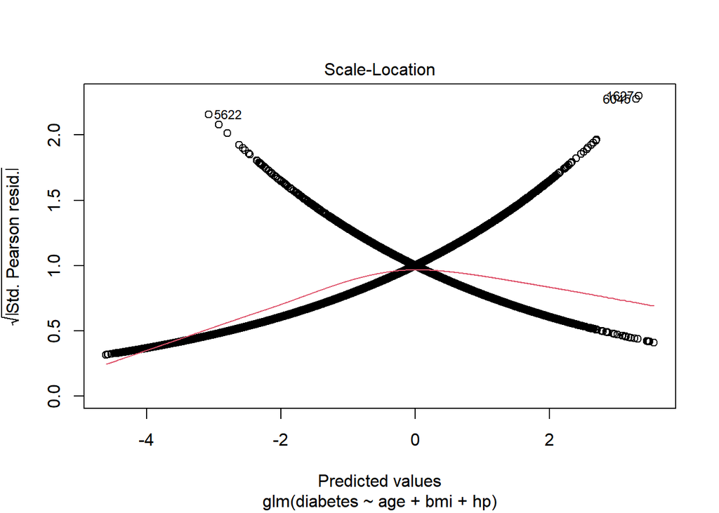

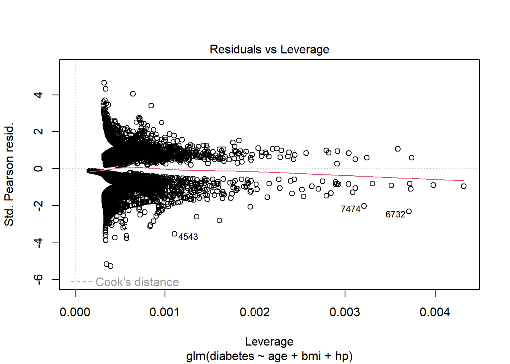

```r
plot(model_logistic)
```

## 7. 결정 나무 (2변수와 다변량 모델 + 가지치기)

- 결정나무(Decision Tree)는 변수 공간을 여러 영역으로 나누어 각 영역마다 같은 예측값을 갖도록 하는 모델입니다.
- 해석이 쉽고 비선형 관계를 잡아낼 수 있지만, 깊게 성장하면 과적합(overfitting)이 발생할 수 있습니다.
- 이를 방지하기 위해 가지치기(pruning) 를 수행하여 최적의 복잡도를 선택합니다
- 결정 나무의 경우에는 분류로 사용하려면 반응변수에 `factor` 형태의 변수를 넣어야 합니다. `as.factor()`를 사용하여 당뇨병 여부를 `factor`로 변환하고 이를 `diabetes_factor`에 저장합니다.

```r
hn19 <- hn19 %>% mutate(diabetes_factor = as.factor(diabetes))
```

- 주어진 데이터에서 우선 설명변수를 2개 사용하여 `age`, `bmi`를 설명변수로, `diabetes`를 반응변수로 하는 분류 결정나무를 적합합니다.
- R에서 결정나무를 적합하는 경우 `rpart` 패키지의 `rpart`()`함수를 이용합니다. 문법은`lm`과 대동소이합니다. 함수 호출 시 전달해야 하는 인자는 다음과 같습니다.
  - formula: 적합할 회귀모형의 형태를 나타냅니다. 반응변수 ~ 설명변수1 + $\cdots$ + 설명변수p의 형태와 같이 반응변수와 설명변수는 ~로 연결하고, 설명변수끼리는 +로 연결합니다. 이 예제의 경우 반응변수는 `diabetes`, 설명변수는 `age`, `bmi`이므로 다음과 같이 인자를 전달할 수 있습니다. `formula = diabetes ~ age + bmi`
  - data: 사용할 데이터를 명시합니다. 앞의 formula에서 명시된 변수들이 인자로 전달되는 데이터에 모두 포함되어 있어야 합니다. 우리의 경우 데이터를 `hn19`라는 변수명으로 저장하였으므로 `data = hn19`와 같이 인자를 전달합니다.
  - method: 분류 결정나무를 사용하는 경우 `"class"`을 사용합니다.
- `rpart.plot()` 함수를 사용해 적합한 결정나무를 시각화합니다.

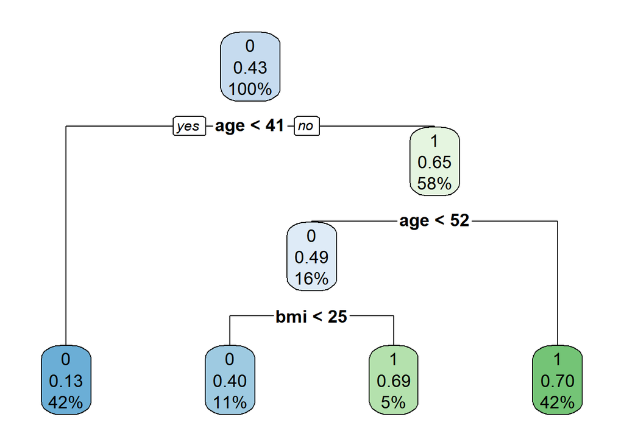

```r
model_tree_2d <- rpart(
  diabetes_factor ~ age + bmi,
  data = hn19,
  method = "class"
)
rpart.plot(model_tree_2d, type = 2, extra = 106, cex = 1.2)
```

- 앞에서와 마찬가지로 시각화를 합니다. 격자 데이터는 앞에서 생성한 `grid`를 이용합니다.
- 격자의 각 지점별 당뇨 확률을 계산해 `pred_tree_2d`에 저장합니다.
- `ggplot()`을 이용해 색상으로 시각화합니다.
- 결정 나무의 경우에는 경계선이 항상 축과 평행하게 나옴을 알 수 있습니다.

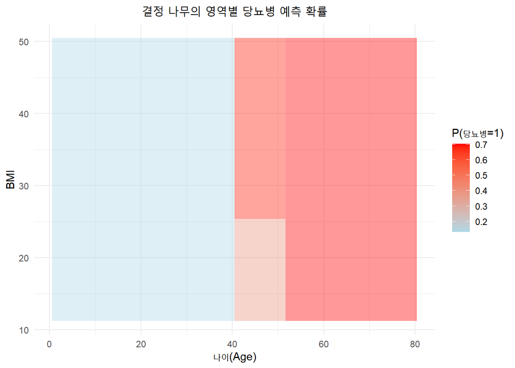

```r
pred_tree_2d <-
  predict(model_tree_2d, newdata = grid, type = "prob")[, 2]

ggplot() +
  geom_tile(
    aes(
      x = grid[["age"]],
      y = grid[["bmi"]],
      fill = pred_tree_2d
    ),
    alpha = 0.4
  ) +
  scale_fill_gradient(low = "lightblue", high = "red") +
  labs(
    title = "결정 나무의 영역별 당뇨병 예측 확률",
    x = "나이(Age)",
    y = "BMI",
    fill = "P(당뇨병=1)"
  ) +
  theme_minimal() +
  theme(plot.title = element_text(hjust = 0.5))
```

- 이번에는 설명변수를 3개 사용하여 `age`, `bmi`, `hp`를 설명변수로, `diabetes`를 반응변수로 하는 분류 결정나무를 적합하고 가지치기(pruning)을 합니다.
- `control`은 결정나무를 적합하는 데 추가적으로 사용하는 옵션을 지정해 줍니다. 나중에 가지치기를 하기 위해, 우선 `cp = 0.001`로 설정하여 우선 결정나무를 충분히 복잡하게 만듭니다.

```r
model_tree <- rpart(
  diabetes_factor ~ age + bmi + hp,
  data = hn19,
  method = "class",
  control = rpart.control(cp = 0.001)
)
```

- `printcp()` 함수로 각 단계에서의 cp 값을 출력합니다.
- `best_cp`에는 교차검증 오차가 최소가 되는 cp 값이 저장되게 됩니다.
- `prune()` 함수로 가지치기(pruning)을 해서 최적의 결정나무를 `model_ptree`에 저장합니다.
- `rpart.plot()` 함수를 사용해 가지치기한 결정나무를 시각화합니다.

```r
printcp(model_tree)
```

```
##
## Classification tree:
## rpart(formula = diabetes_factor ~ age + bmi + hp, data = hn19,
##     method = "class", control = rpart.control(cp = 0.001))
##
## Variables actually used in tree construction:
## [1] age bmi hp
##
## Root node error: 3310/7670 = 0.43155
##
## n= 7670
##
##          CP nsplit rel error  xerror     xstd
## 1 0.3927492      0   1.00000 1.00000 0.013105
## 2 0.0253776      1   0.60725 0.60906 0.011647
## 3 0.0021148      3   0.55650 0.56979 0.011394
## 4 0.0015710      8   0.54411 0.56949 0.011392
## 5 0.0013595     15   0.53263 0.56284 0.011346
## 6 0.0012085     17   0.52991 0.55559 0.011296
## 7 0.0010070     32   0.50906 0.55529 0.011294
## 8 0.0010000     35   0.50604 0.55498 0.011292
```

[figure not shown]

```r
best_cp <- model_tree$cptable[which.min(model_tree$cptable[, "xerror"]), "CP"]
model_ptree <- prune(model_tree, cp = best_cp)
rpart.plot(model_ptree, type = 2, extra = 106, cex = 1)
```

## 8. 앙상블 모형(배깅, 랜덤 포레스트)

- 배깅(Bagging) 은 여러 부트스트랩 샘플에 대해 모델(결정나무)을 학습하고 예측을 평균/다수결로 결합합니다.
- 랜덤 포레스트(Random Forest) 는 배깅에 변수 무작위 선택을 추가하여 상관성을 줄이고 성능을 향상시킵니다.
- 배깅과 랜덤 포레스트는 모두 `randomForest` 패키지의 `randomForest()` 함수로 적합할 수 있습니다. 이는 랜덤 포레스트에서 변수의 개수를 전부 다 쓰면 그게 배깅이 되기 때문입니다.
- 앞에서와 마찬가지로 설명변수를 3개 사용하여 `age`, `bmi`, `hp`를 설명변수로, `diabetes`를 반응변수로 하는 앙상블 모형을 생각합니다.
- 우선 배깅 모형을 적합합니다. 이는 `randomForest()` 함수에서 사용하는 설명변수의 개수를 전체 설명변수의 개수인 3으로 지정하면 됩니다 (mtry=3).
- `print()` 함수로 적합한 배깅 모형의 요약 정보를 출력합니다.
- `plot()` 함수로 적합한 트리 수에 따른 오차 변화를 확인합니다.

```r
model_bag <- randomForest(
  diabetes_factor ~ age + bmi + hp,
  data = hn19,
  mtry = 3,
  ntree = 100,
  importance = TRUE
)
print(model_bag)
```

```
##
## Call:
##  randomForest(formula = diabetes_factor ~ age + bmi + hp, data = hn19,      mtry = 3, ntree = 100, importance = TRUE)
##                Type of random forest: classification
##                      Number of trees: 100
## No. of variables tried at each split: 3
##
##         OOB estimate of  error rate: 28.45%
## Confusion matrix:
##      0    1 class.error
## 0 3220 1140   0.2614679
## 1 1042 2268   0.3148036
```

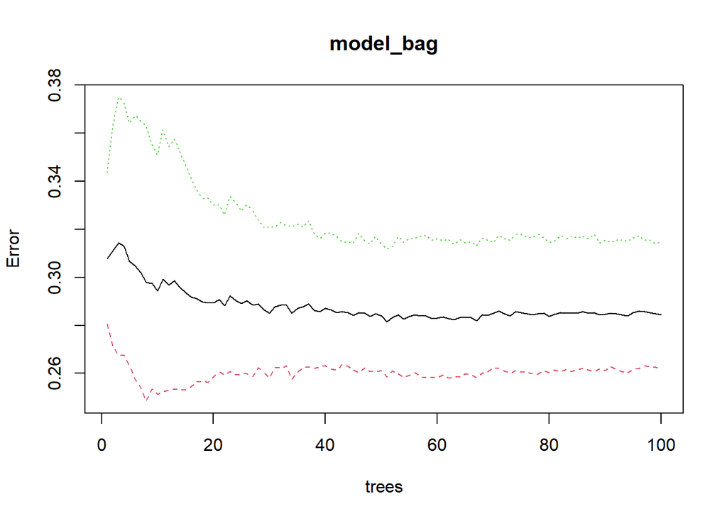

```r
plot(model_bag)
```

- 다음으로 랜덤포레스트 모형을 적합합니다. 이는 `randomForest()` 함수에서 사용하는 설명변수의 개수를 전체 설명변수의 개수보다 적게 지정하면 됩니다. (mtry=2).
- `print()` 함수로 적합한 배깅 모형의 요약 정보를 출력합니다.
- `plot()` 함수로 적합한 트리 수에 따른 오차 변화를 확인합니다.

```r
model_rf <- randomForest(
  diabetes_factor ~ age + bmi + hp,
  data = hn19,
  mtry = 2,
  ntree = 100,
  importance = TRUE
)
print(model_rf)
```

```
##
## Call:
##  randomForest(formula = diabetes_factor ~ age + bmi + hp, data = hn19,      mtry = 2, ntree = 100, importance = TRUE)
##                Type of random forest: classification
##                      Number of trees: 100
## No. of variables tried at each split: 2
##
##         OOB estimate of  error rate: 27.46%
## Confusion matrix:
##      0    1 class.error
## 0 3222 1138   0.2610092
## 1  968 2342   0.2924471
```

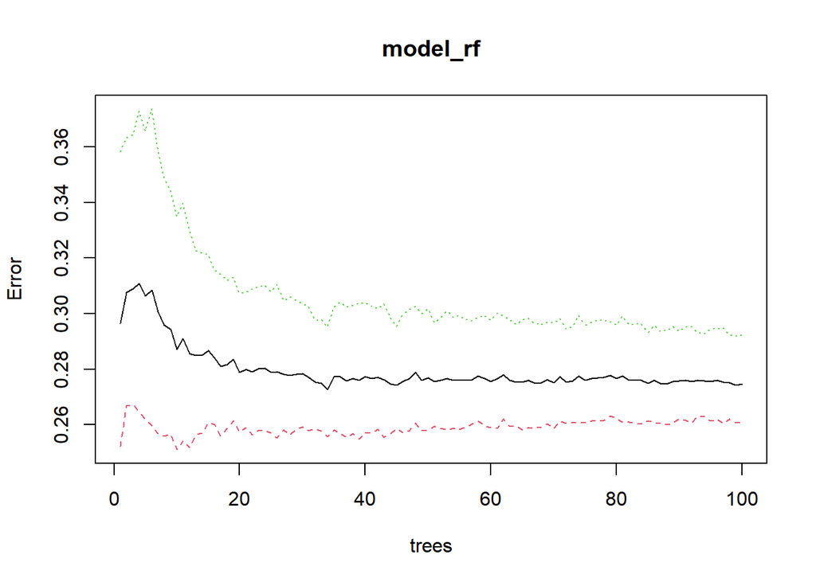

```r
plot(model_rf)
```

## 9. 신경망 모형 (Neural Network)

- 신경망(Neural Network)은 입력층, 은닉층, 출력층으로 구성되며, 비선형 관계 학습에 강점이 있습니다.
- 충분한 데이터와 계산 자원이 필요하지만, 복잡한 패턴을 학습할 수 있습니다.
- 앞에서와 마찬가지로 설명변수를 3개 사용하여 `age`, `bmi`, `hp`를 설명변수로, `diabetes`를 반응변수로 하는, 은닉층(hidden layer)이 하나인 신경망 모형을 생각합니다.
- 신경망 모형을 적합하는 패키지는 여러 가지 있지만, 여기서는 가장 간단하게 할 수 있는 `neuralnet` 패키지의 `neuralnet()` 함수를 소개합니다. 다만 이 패키지는 느린 편이어서, 더 복잡한 자료에서는 `keras` 패키지 내지는 `torch` 패키지를 사용하면 좀 더 빠르게 실행할 수 있습니다.
- 속도가 느린 관계로 `hn19[1:100, ]` 명령어로 처음 100개의 행만 골라냅니다.
- `hidden`은 은닉층(hidden layer)의 뉴런 수입니다. 아래에서는 `hidden = 2` 를 사용했습니다.
- 출력층은 로지스틱 회귀처럼 0~1 범위의 확률을 출력하도록 `linear.output = FALSE` 사용합니다.
- `plot()` 함수로 신경망 구조를 시각화합니다.

```r
model_nn <- neuralnet(
  diabetes ~ age + bmi + hp,
  data = hn19[1:100, ],
  hidden = 2,
  linear.output = FALSE
)
plot(model_nn)
```

[output not shown]

## 10. 모델 평가 (데이터 분리, Threshold 성능 분석, ROC Curve)

- 혼동행렬, 민감도, 특이도(Slide 60~64)로 모델 성능을 평가합니다.
- threshold 변화에 따른 민감도·특이도 변화(ROC Curve)를 시각화하고, AUC를 계산해 분류기 성능을 종합적으로 판단합니다.
- 학습용/테스트용 데이터 분리를 통해 과대적합을 방지합니다.
- 우선 학습용/테스트용 데이터(training data/test data)를 10% 대 90%로 분리합니다. `caret` 패키지의 `createDataPartition()` 함수를 사용합니다.

```r
set.seed(2025)
id_train <- createDataPartition(hn19[["diabetes"]], p = 0.1, list = FALSE)
hn19_train <- hn19[id_train, ]
hn19_test <- hn19[-id_train, ]
```

- 다음으로,threshold 별 평가 지표(accuracy, sensitivity, specificity)를 한 번에 계산하는 코드를 함수로 작성합니다.
- `thresholds` 에는 threshold 의 값이 벡터로 들어옵니다.
- `actual`은 실제 반응변수의 값, `predicted`는 예측된 반응변수의 값이 들어옵니다. 단, 여기서 `predicted`는 확률로 값이 들어가야 합니다.

```r
calc_metrics <- function(thresholds, actual, predicted) {

  # threshold 하나에 대해 평가 지표를 계산
  metrics_one <- function(threshold, actual, predicted) {
    # 예측 확률이 threshold보다 크면 1(양성), 작으면 0(음성)
    pred_class <- ifelse(predicted > threshold, 1, 0)

    # 혼동 행렬 요소 계산
    TP <- sum(pred_class == 1 & actual == 1) # 참 양성
    TN <- sum(pred_class == 0 & actual == 0) # 참 음성
    FP <- sum(pred_class == 1 & actual == 0) # 거짓 양성
    FN <- sum(pred_class == 0 & actual == 1) # 거짓 음성

    # 평가 지표 계산
    accuracy <- (TP + TN) / (TP + TN + FP + FN)
    sensitivity <- TP / (TP + FN)   # 재현율
    specificity <- TN / (TN + FP)   # 특이도
    c(accuracy, sensitivity, specificity)
  }

  # 모든 threshold에 대해 metrics_one 계산
  results <- data.frame(
    threshold = thresholds,
    t(sapply(thresholds, function(t) metrics_one(t, actual, predicted)))
  )
  colnames(results) <- c("threshold", "Accuracy", "Sensitivity", "Specificity")
  results
}
```

- thresholds 후보를 0부터 1까지 0.01 단위의 벡터로 만듭니다.

```r
thresholds <- seq(0, 1, by = 0.01)
id_05 <- which(thresholds == 0.5)
```

```r
model_logistic <- glm(
  diabetes ~ age + bmi + hp,
  data = hn19_test,
  family = "binomial"
)
pred_logistic <- predict(model_logistic, newdata = hn19_test, type = "response")
```

- 앞에서 작성한 `calc_metrics()` 함수로 threshold 변화 시 accuracy, sensitivity, specificity 를 계산합니다. 특히나, accuracy 에서 `threshold = 0.5`에 해당하는 값이 우리가 일반적으로 생각하는 정확도입니다.

```r
metric_logistic <- calc_metrics(thresholds, hn19_test[["diabetes"]], pred_logistic)
cat("Logistic Accuracy:", round(metric_logistic[["Accuracy"]][id_05], 3), "\n")
```

```
## Logistic Accuracy: 0.756
```

- 위에서 계산한 값을 바탕으로 accuracy, sensitivity, specificity 를 시각화합니다.

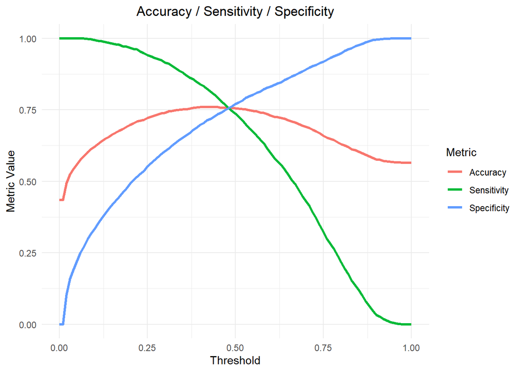

```r
metric_logistic_long <- metric_logistic %>%
  pivot_longer(
    cols = c("Accuracy", "Sensitivity", "Specificity"),
    names_to = "Metric",
    values_to = "Value"
  )
ggplot(metric_logistic_long, aes(x = threshold, y = Value, color = Metric)) +
  geom_line(size = 1.2) +
  labs(title = "Accuracy / Sensitivity / Specificity", x = "Threshold", y = "Metric Value") +
  theme_minimal() +
  theme(plot.title = element_text(hjust = 0.5))
```

- ROC curve 를 계산 및 시각화하고 AUC 를 계산합니다. `pROC` 패키지의 `roc()` 함수를 이용하면 됩니다.

```r
roc_obj <- roc(hn19_test[["diabetes"]], pred_logistic)
```

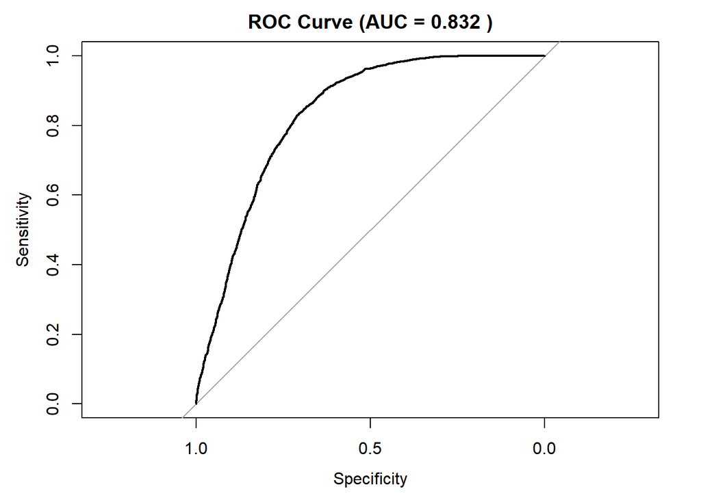

```r
plot(roc_obj, main = paste("ROC Curve (AUC =", round(roc_obj$auc, 3), ")"))
```

# 연습문제

- 똑같은 데이터를 사용합니다.

## 1. 로지스틱 회귀 모형

- 설명변수를 1개 사용하여 `bmi`를 설명변수로, `diabetes`를 반응변수로 하는 로지스틱 회귀모형을 적합합니다.
- 4단계에서 그린 BMI와 당뇨병 관계 시각화에 더해서 BMI 값 별로 로지스틱 회귀모형의 당뇨병 예측 확률을 곡선으로 그립니다. `geom_line(aes(y = pred_logistic))`과 같은 형태로 할 수 있습니다.

### 풀이

- 우선 아래와 같이 BMI와 당뇨병 관계를 시각화는 코드를 가져옵니다.

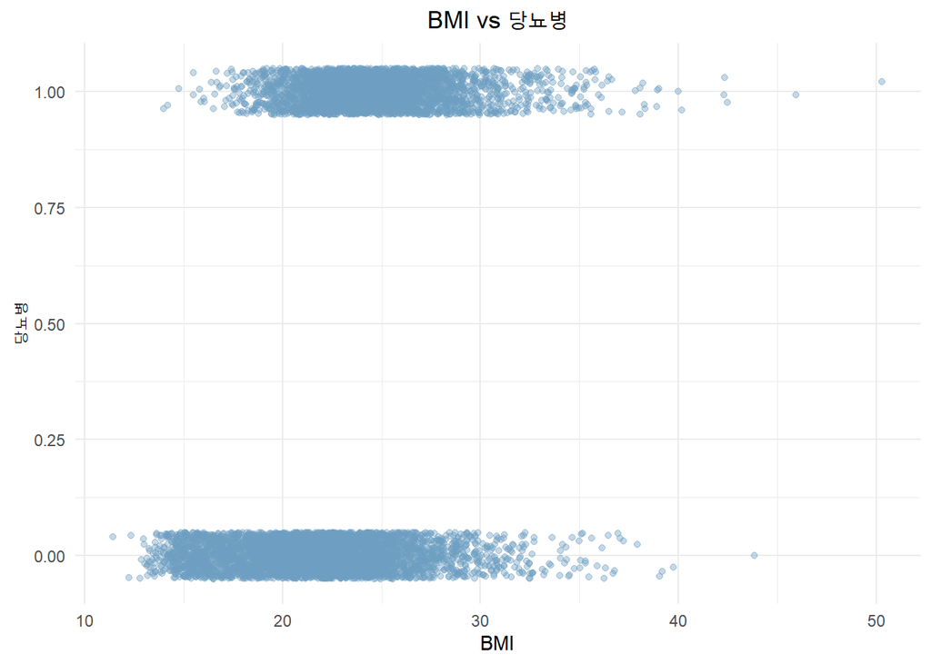

```r
p <- ggplot(hn19, aes(x = bmi, y = diabetes)) +
  geom_jitter(
    color = "#6D9EC1",
    height = 0.05,
    width = 0,
    alpha = 0.4
  ) +
  labs(
    title = "BMI vs 당뇨병",
    x = "BMI",
    y = "당뇨병"
  ) +
  theme_minimal() +
  theme(plot.title = element_text(hjust = 0.5))

p
```

- 이제 `bmi`를 설명변수로, `diabetes`를 반응변수로 하는 로지스틱 회귀모형을 적합합니다.

```r
model_logistic_bmi <- glm(
  formula = diabetes ~ bmi,
  data = hn19,
  family = "binomial"
)
```

- `bmi`에 해당하는 격자를 `grid_bmi`로 생성합니다.
- 격자의 각 지점별 당뇨 확률을 계산해 `grid_bmi[["pred_logistic"]]`에 저장합니다.
- `ggplot()`의 `geom_line()`을 이용해 회귀곡선을 시각화합니다. `grid_bmi`의 `bmi`에 격자가, `pred_logistic`에 당뇨 확률이 계산돼 있으므로 `aes(x = bmi, y = pred_logistic)` 같은 식으로 코드를 작성하면 됩니다.

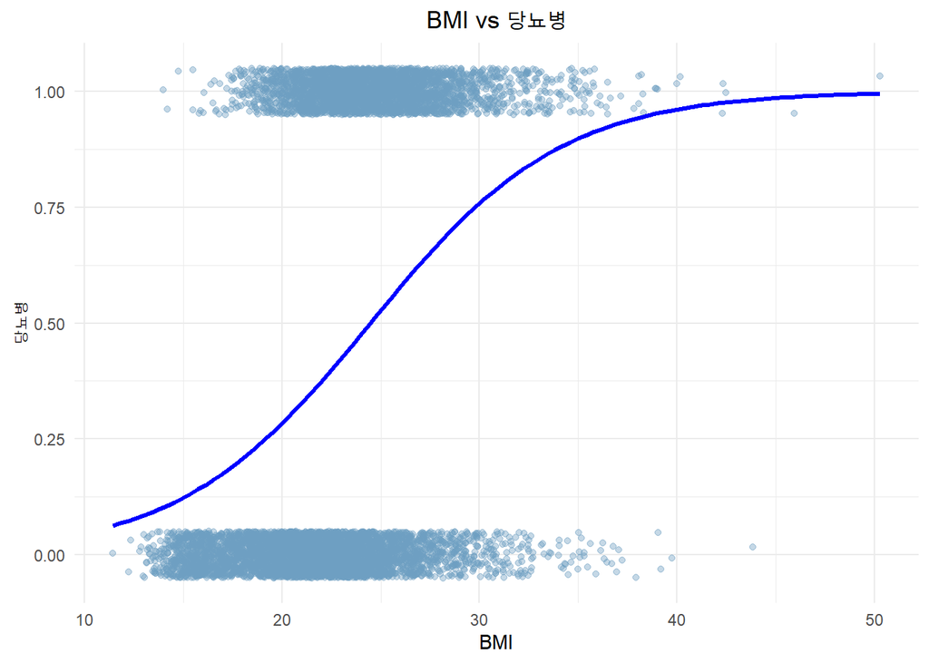

```r
grid_bmi <- data.frame(
  bmi = seq(min(hn19[["bmi"]]), max(hn19[["bmi"]]), length.out = 100))

grid_bmi[["pred_logistic"]] <- predict(
  model_logistic_bmi,
  newdata = grid_bmi,
  type = "response"
)

p <- p +
  geom_line(data = grid_bmi, aes(x = bmi, y = pred_logistic),
    color = "blue", size = 1.2)
p
```

## 2. 결정나무

- 설명변수를 1개 사용하여 `bmi`를 설명변수로, `diabetes`를 반응변수로 하는 분류 결정나무를 적합합니다. 가지치기는 따로 안해도 됩니다.
- 4단계에서 그린 BMI와 당뇨병 관계 시각화에 더해서 BMI 값 별로 분류 결정나무의 당뇨병 예측 확률을 곡선으로 그립니다. `geom_line(aes(y = pred_tree))`과 같은 형태로 할 수 있습니다.

### 풀이

- 우선 아래와 같이 BMI와 당뇨병 관계를 시각화는 코드를 가져옵니다.

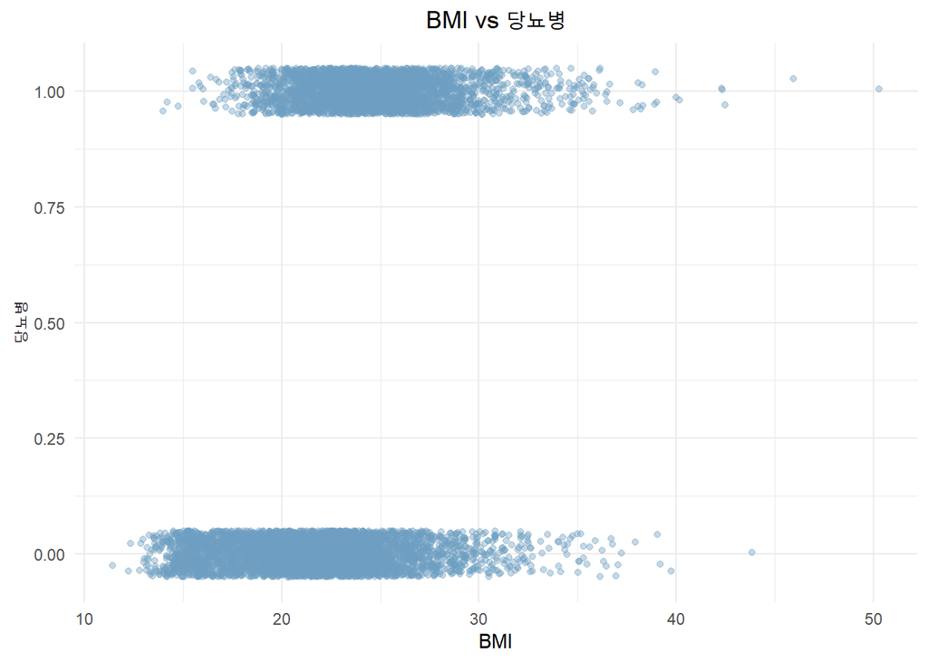

```r
p <- ggplot(hn19, aes(x = bmi, y = diabetes)) +
  geom_jitter(
    color = "#6D9EC1",
    height = 0.05,
    width = 0,
    alpha = 0.4
  ) +
  labs(
    title = "BMI vs 당뇨병",
    x = "BMI",
    y = "당뇨병"
  ) +
  theme_minimal() +
  theme(plot.title = element_text(hjust = 0.5))

p
```

- 이제 `bmi`를 설명변수로, `diabetes`를 반응변수로 하는 분류 결정나무를 적합합니다.

```r
model_tree_bmi <- rpart(
  diabetes_factor ~ bmi,
  data = hn19,
  method = "class"
)
```

- 앞 문제의 `grid_bmi`를 `bmi`에 해당하는 격자로 활용합니다.
- 격자의 각 지점별 당뇨 확률을 계산해 `grid_bmi[["pred_tree"]]`에 저장합니다.
- `ggplot()`의 `geom_line()`을 이용해 회귀곡선을 시각화합니다. `grid_bmi`의 `bmi`에 격자가, `pred_tree`에 당뇨 확률이 계산돼 있으므로 `aes(x = bmi, y = pred_tree)` 같은 식으로 코드를 작성하면 됩니다.

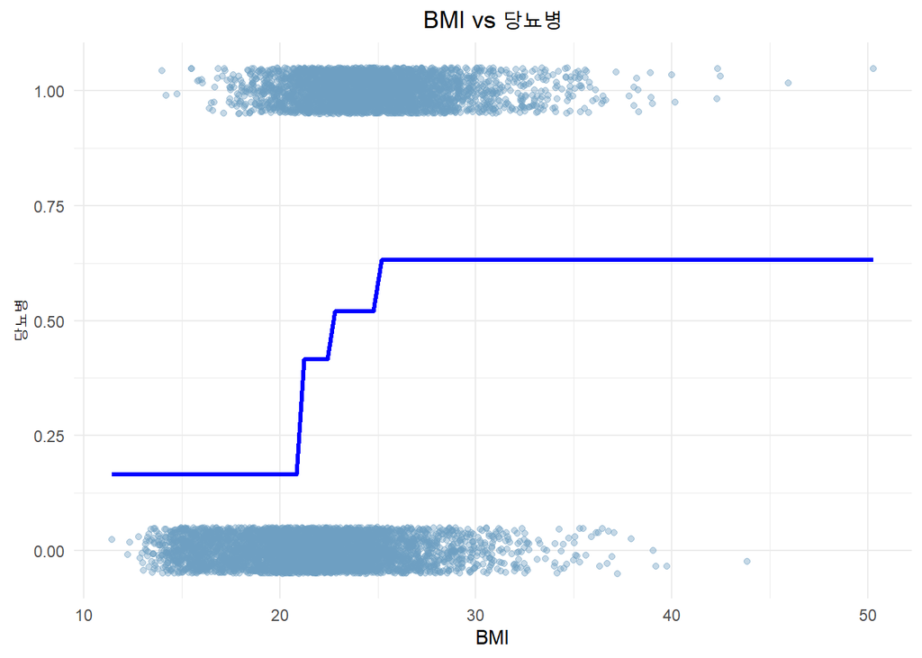

```r
grid_bmi[["pred_tree"]] <- predict(
  model_tree_bmi,
  newdata = grid_bmi,
  type = "prob"
)[, 2]

p <- p +
  geom_line(data = grid_bmi, aes(x = bmi, y = pred_tree),
    color = "blue", size = 1.2)
p
```

## 3. 배깅

- 설명변수를 2개 사용하여 `age`, `bmi`를 설명변수로, `diabetes`를 반응변수로 하는 배깅 모형을 적합합니다.
- 5단계 마지막에서 했던 것처럼 age 및 BMI 값 별로 배깅 모형의 당뇨병 예측 확률을 색칠해 나타냅니다.

### 풀이

- 우선 설명변수를 2개 사용하여 `age`, `bmi`를 설명변수로, `diabetes`를 반응변수로 하는 배깅 모형을 적합합니다.

```r
model_bag_2d <- randomForest(
  diabetes_factor ~ age + bmi,
  data = hn19,
  mtry = 2,
  ntree = 100,
  importance = TRUE
)
```

- 그러고서는 5단계 마지막에 했던 시각화를 반복합니다.
- 우선 격자 데이터를 `grid`에 생성합니다.
- 격자의 각 지점별 당뇨 확률을 계산해 `pred_bag_2d`에 저장합니다.
- `ggplot()`을 이용해 색상으로 시각화합니다.

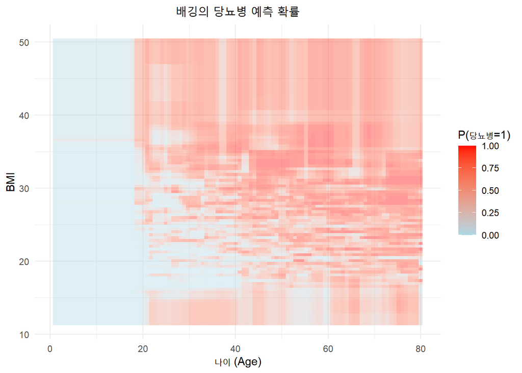

```r
age_seq <- seq(min(hn19$age), max(hn19$age), length.out = 100)
bmi_seq <- seq(min(hn19$bmi), max(hn19$bmi), length.out = 100)
grid <- expand.grid(age = age_seq, bmi = bmi_seq)

pred_bag_2d <- predict(
  model_bag_2d,
  newdata = grid,
  type = "prob"
)[, 2]

ggplot() +
  geom_tile(
    aes(
      x = grid[["age"]],
      y = grid[["bmi"]],
      fill = pred_bag_2d
    ),
    alpha = 0.4
  ) +
  scale_fill_gradient(low = "lightblue", high = "red") +
  labs(
    title = "배깅의 당뇨병 예측 확률",
    x = "나이 (Age)",
    y = "BMI",
    fill = "P(당뇨병=1)"
  ) +
  theme_minimal() +
  theme(plot.title = element_text(hjust = 0.5))
```

## 4. 랜덤 포레스트

- 설명변수를 2개 사용하여 `age`, `bmi`를 설명변수로, `diabetes`를 반응변수로 하는 랜덤 포레스트 모형을 적합합니다.
- 5단계 마지막에서 했던 것처럼 age 및 BMI 값 별로 랜덤 포레스트 모형의 당뇨병 예측 확률을 색칠해 나타냅니다.

### 풀이

- 우선 설명변수를 2개 사용하여 `age`, `bmi`를 설명변수로, `diabetes`를 반응변수로 하는 랜덤 포레스트 모형을 적합합니다.

```r
model_rf_2d <- randomForest(
  diabetes_factor ~ age + bmi,
  data = hn19,
  mtry = 1,
  ntree = 100,
  importance = TRUE
)
```

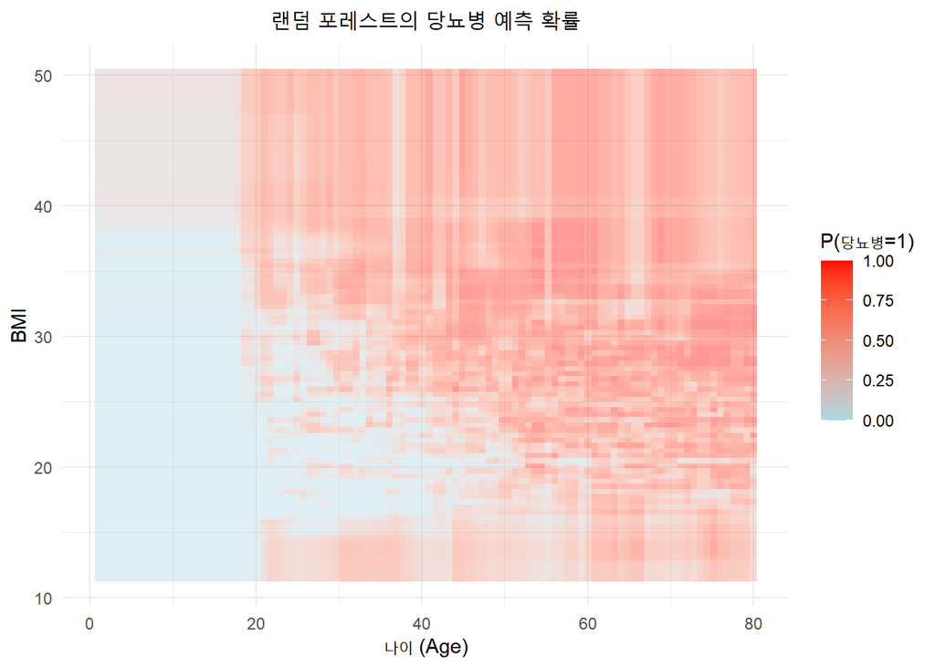

```r
age_seq <- seq(min(hn19$age), max(hn19$age), length.out = 100)
bmi_seq <- seq(min(hn19$bmi), max(hn19$bmi), length.out = 100)
grid <- expand.grid(age = age_seq, bmi = bmi_seq)

pred_rf_2d <- predict(
  model_rf_2d,
  newdata = grid,
  type = "prob"
)[, 2]

ggplot() +
  geom_tile(
    aes(
      x = grid[["age"]],
      y = grid[["bmi"]],
      fill = pred_rf_2d
    ),
    alpha = 0.4
  ) +
  scale_fill_gradient(low = "lightblue", high = "red") +
  labs(
    title = "랜덤 포레스트의 당뇨병 예측 확률",
    x = "나이 (Age)",
    y = "BMI",
    fill = "P(당뇨병=1)"
  ) +
  theme_minimal() +
  theme(plot.title = element_text(hjust = 0.5))
```

## 5. 인공 신경망

- 설명변수를 2개 사용하여 `age`, `bmi`를 설명변수로, `diabetes`를 반응변수로 하는 인공 신경망을 적합합니다.
- 5단계 마지막에서 했던 것처럼 age 및 BMI 값 별로 인공 신경망 모형의 당뇨병 예측 확률을 색칠해 나타냅니다.

### 풀이

- 우선 설명변수를 2개 사용하여 `age`, `bmi`를 설명변수로, `diabetes`를 반응변수로 하는 인공 신경망을 적합합니다.

```r
model_nn_2d <- neuralnet(
  diabetes ~ age + bmi,
  data = hn19[1:100, ],
  hidden = 2,
  linear.output = FALSE
)
plot(model_nn_2d)
```

[output not shown]

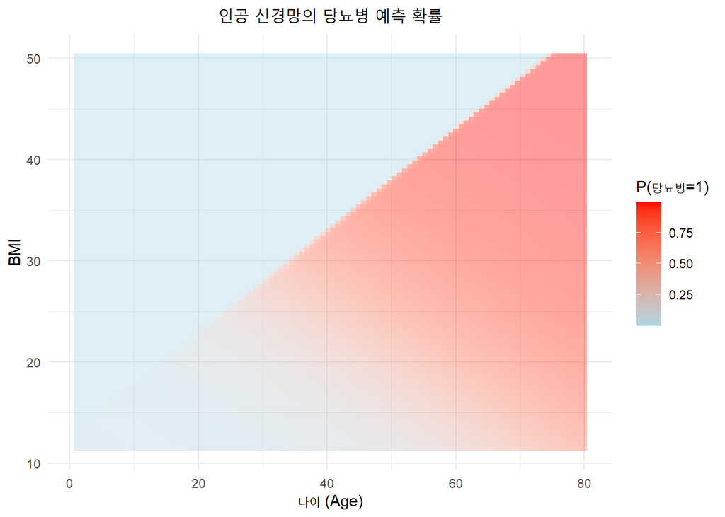

```r
pred_nn_2d <- predict(
  model_nn_2d,
  newdata = grid,
  type = "prob"
)

ggplot() +
  geom_tile(
    aes(
      x = grid[["age"]],
      y = grid[["bmi"]],
      fill = pred_nn_2d
    ),
    alpha = 0.4
  ) +
  scale_fill_gradient(low = "lightblue", high = "red") +
  labs(
    title = "인공 신경망의 당뇨병 예측 확률",
    x = "나이 (Age)",
    y = "BMI",
    fill = "P(당뇨병=1)"
  ) +
  theme_minimal() +
  theme(plot.title = element_text(hjust = 0.5))
```

## 6. 모델 평가

- 설명변수를 3개 사용하여 `age`, `bmi`, `hp`를 설명변수로, `diabetes`를 반응변수로 하는 모형을 생각합니다.
- 위 실습에서는 로지스틱 회귀모형에 대해서 accuracy, sensitivity, specificity 의 곡선을 그리고 roc curve 를 그렸습니다. 이를 결정나무, 배깅, 랜덤 포레스트, 인공신경망에 대해 반복합니다.

### 풀이

- 앞에서처럼 학습용/테스트용 데이터(training data/test data)를 10% 대 90%로 분리합니다. `caret` 패키지의 `createDataPartition()` 함수를 사용합니다.

```r
set.seed(2025)
id_train <- createDataPartition(hn19[["diabetes"]], p = 0.1, list = FALSE)
hn19_train <- hn19[id_train, ]
hn19_test <- hn19[-id_train, ]
```

- 앞에서 작성했던 threshold 별 평가 지표(accuracy, sensitivity, specificity)를 한 번에 계산하는 `calc_metrics` 함수를 가져옵니다.

```r
calc_metrics <- function(thresholds, actual, predicted) {

  # threshold 하나에 대해 평가 지표를 계산
  metrics_one <- function(threshold, actual, predicted) {
    # 예측 확률이 threshold보다 크면 1(양성), 작으면 0(음성)
    pred_class <- ifelse(predicted > threshold, 1, 0)

    # 혼동 행렬 요소 계산
    TP <- sum(pred_class == 1 & actual == 1) # 참 양성
    TN <- sum(pred_class == 0 & actual == 0) # 참 음성
    FP <- sum(pred_class == 1 & actual == 0) # 거짓 양성
    FN <- sum(pred_class == 0 & actual == 1) # 거짓 음성

    # 평가 지표 계산
    accuracy <- (TP + TN) / (TP + TN + FP + FN)
    sensitivity <- TP / (TP + FN)   # 재현율
    specificity <- TN / (TN + FP)   # 특이도
    c(accuracy, sensitivity, specificity)
  }

  # 모든 threshold에 대해 metrics_one 계산
  results <- data.frame(
    threshold = thresholds,
    t(sapply(thresholds, function(t) metrics_one(t, actual, predicted)))
  )
  colnames(results) <- c("threshold", "Accuracy", "Sensitivity", "Specificity")
  results
}
```

- 여기에 더해, accuracy, sensitivity, specificity 를 시각화하는 함수, roc curve 를 그리는 함수를 각각 만듭니다.

```r
plot_metrics <- function(thresholds, actual, predicted) {

  metric <- calc_metrics(thresholds, actual, predicted)

  metric_long <- metric %>%
  pivot_longer(
    cols = c("Accuracy", "Sensitivity", "Specificity"),
    names_to = "Metric",
    values_to = "Value"
  )

  ggplot(metric_long, aes(x = threshold, y = Value, color = Metric)) +
  geom_line(size = 1.2) +
  labs(title = "Accuracy / Sensitivity / Specificity", x = "Threshold", y = "Metric Value") +
  theme_minimal() +
  theme(plot.title = element_text(hjust = 0.5))
}

plot_roc <- function(actual, predicted) {

  roc_obj <- roc(actual, predicted)
  plot(roc_obj, main = paste("ROC Curve (AUC =", round(roc_obj[["auc"]], 3), ")"))
}
```

- 앞에서처럼 thresholds 후보를 0부터 1까지 0.01 단위의 벡터로 만듭니다.

```r
thresholds <- seq(0, 1, by = 0.01)
id_05 <- which(thresholds == 0.5)
```

```r
model_tree <- rpart(
  diabetes_factor ~ age + bmi + hp,
  data = hn19,
  method = "class"
)
pred_tree <- predict(model_tree, newdata = hn19_test, type = "prob")[, 2]
```

- 앞에서 작성한 `plot_metrics()` 함수로 threshold 변화 시 accuracy, sensitivity, specificity 를 시각화합니다.

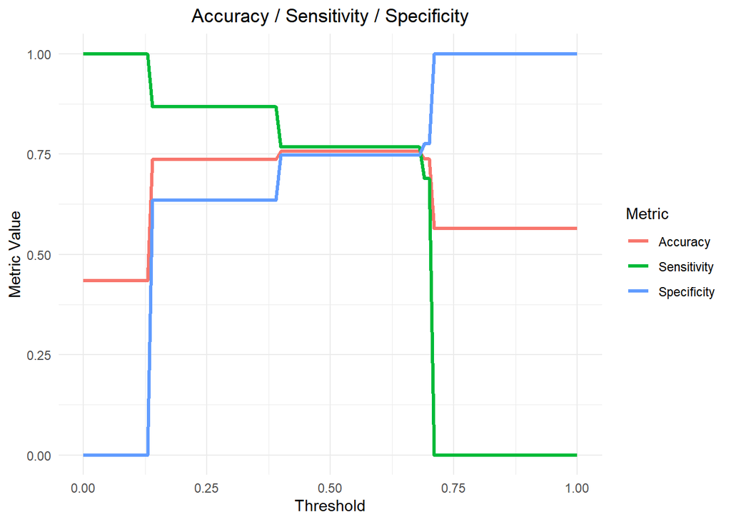

```r
plot_metrics(thresholds, hn19_test[["diabetes"]], pred_tree)
```

- ROC curve 를 계산 및 시각화하고 AUC 를 계산합니다.

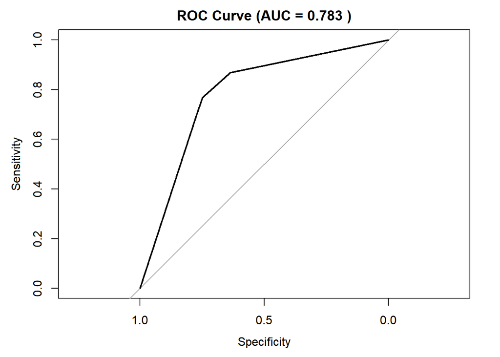

```r
plot_roc(hn19_test[["diabetes"]], pred_tree)
```

- 이제 배깅에 대해 accuracy, sensitivity, specificity 의 곡선을 그리고 roc curve 를 그립니다.
- 학습 데이터(training data)에서 모형을 학습하고, 테스트 데이터(test data)에서 예측 확률을 산출합니다.

```r
model_bag <-  randomForest(
  diabetes_factor ~ age + bmi + hp,
  data = hn19_train,
  mtry = 3,
  ntree = 100,
  importance = TRUE
)
pred_bag <- predict(model_bag, newdata = hn19_test, type = "prob")[, 2]
```

- 앞에서 작성한 `plot_metrics()` 함수로 threshold 변화 시 accuracy, sensitivity, specificity 를 시각화합니다.

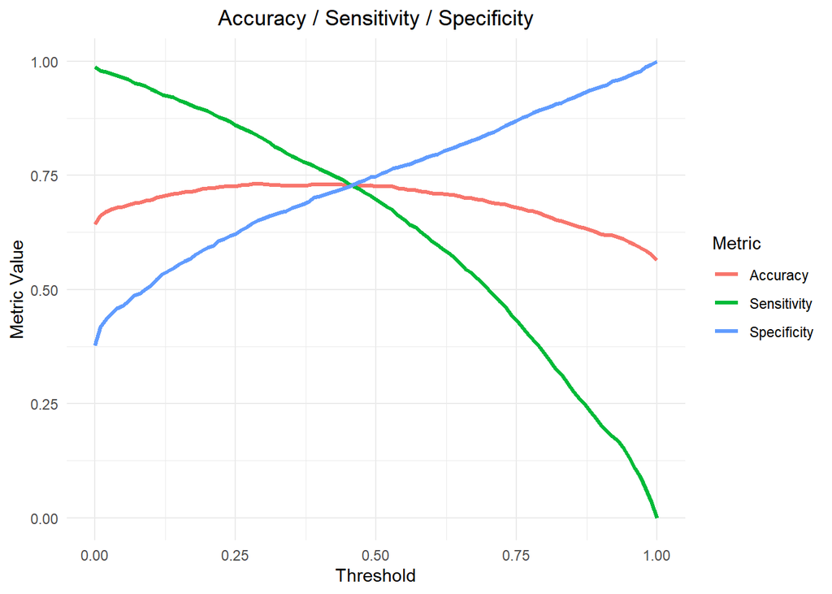

```r
plot_metrics(thresholds, hn19_test[["diabetes"]], pred_bag)
```

- ROC curve 를 계산 및 시각화하고 AUC 를 계산합니다.

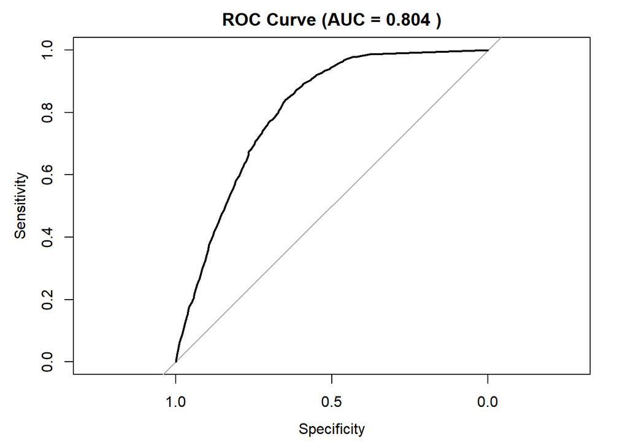

```r
plot_roc(hn19_test[["diabetes"]], pred_bag)
```

- 이제 랜덤포레스트에 대해 accuracy, sensitivity, specificity 의 곡선을 그리고 roc curve 를 그립니다.
- 학습 데이터(training data)에서 모형을 학습하고, 테스트 데이터(test data)에서 예측 확률을 산출합니다.

```r
model_rf <-  randomForest(
  diabetes_factor ~ age + bmi + hp,
  data = hn19_train,
  mtry = 2,
  ntree = 100,
  importance = TRUE
)
pred_rf <- predict(model_rf, newdata = hn19_test, type = "prob")[, 2]
```

- 앞에서 작성한 `plot_metrics()` 함수로 threshold 변화 시 accuracy, sensitivity, specificity 를 시각화합니다.

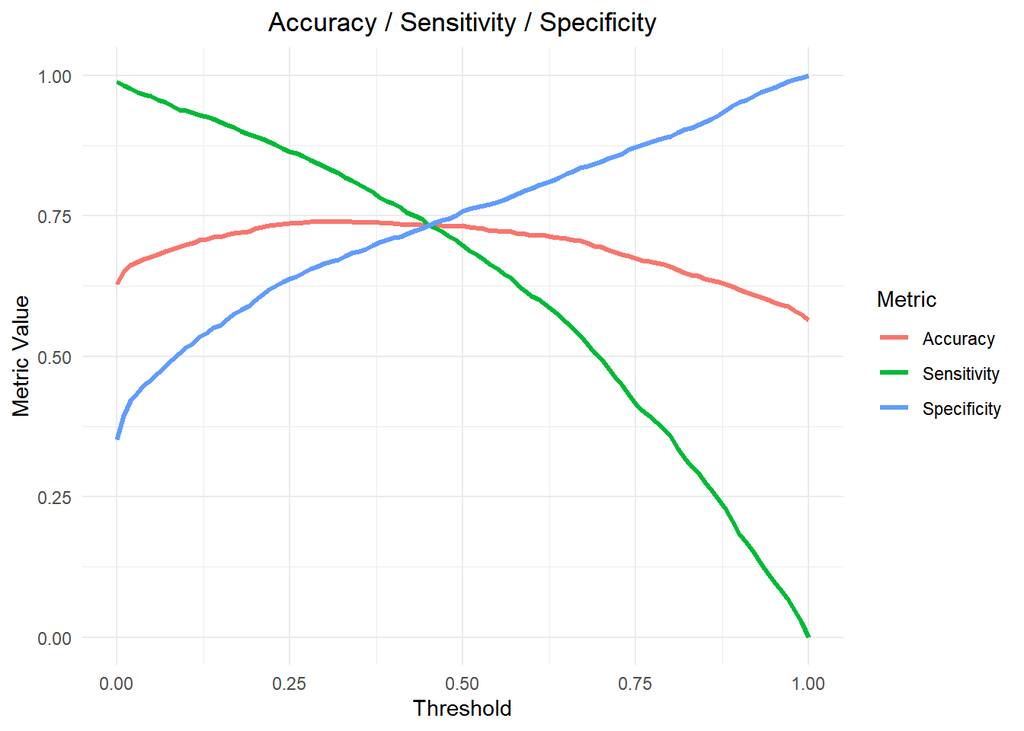

```r
plot_metrics(thresholds, hn19_test[["diabetes"]], pred_rf)
```

- ROC curve 를 계산 및 시각화하고 AUC 를 계산합니다.

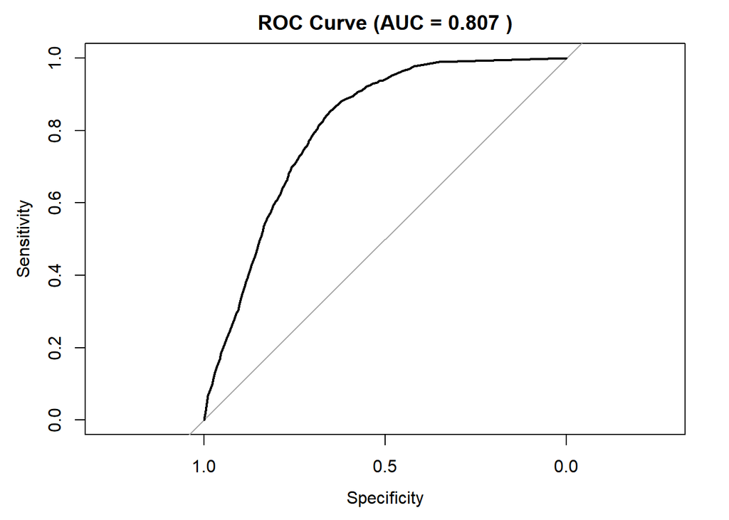

```r
plot_roc(hn19_test[["diabetes"]], pred_rf)
```

- 마지막으로 인공신경망에 대해 accuracy, sensitivity, specificity 의 곡선을 그리고 roc curve 를 그립니다.
- 학습 데이터(training data)에서 모형을 학습하고, 테스트 데이터(test data)에서 예측 확률을 산출합니다.

```r
model_nn <-  neuralnet(
  diabetes ~ age + bmi + hp,
  data = hn19_train,
  hidden = 2,
  linear.output = FALSE
)
pred_nn <- predict(model_nn, newdata = hn19_test, type = "prob")
```

- 앞에서 작성한 `plot_metrics()` 함수로 threshold 변화 시 accuracy, sensitivity, specificity 를 시각화합니다.

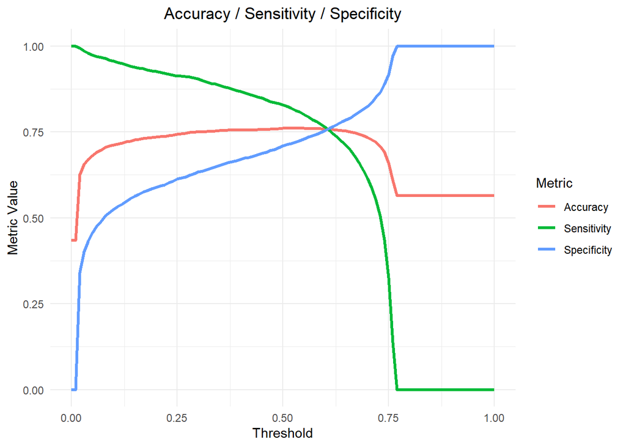

```r
plot_metrics(thresholds, hn19_test[["diabetes"]], pred_nn)
```

- ROC curve 를 계산 및 시각화하고 AUC 를 계산합니다.

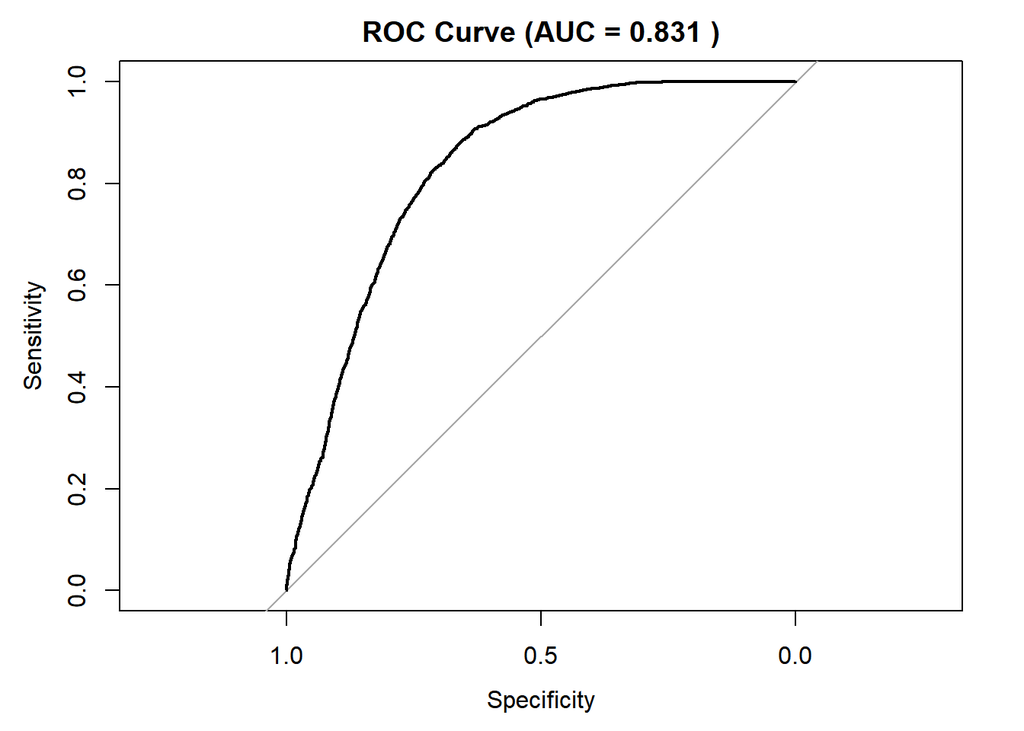

```r
plot_roc(hn19_test[["diabetes"]], pred_nn)
```